**Convolutional Neural Networks (CNN)**

By Prof. Seungchul Lee  
http://iai.postech.ac.kr/  
Industrial AI Lab at POSTECH

Table of Contents

# 1. Convolution

## 1.1. 1D Convolution

[figure not shown]

## 1.2. Convolution on Image (= Convolution in 2D)

**Filter (or Kernel)**

- Modify or enhance an image by filtering
- Filter images to emphasize certain features or remove other features
- Filtering includes smoothing, sharpening and edge enhancement
- Discrete convolution can be viewed as element-wise multiplication by a matrix

[figure not shown]

**How to find the right Kernels**

- We learn many different kernels that make specific effect on images
- Let’s apply an opposite approach
- We are not designing the kernel, but are learning the kernel from data
- Can learn feature extractor from data using a deep learning framework

# 2. Convolutional Neural Networks (CNN)

## 2.1. Motivation: Learning Visual Features

The bird occupies a local area and looks the same in different parts of an image. We should construct neural networks which exploit these properties.

[figure not shown]

- ANN structure for object detecion in image
  - does not seem the best
  - did not make use of the fact that we are dealing with images
  - Spatial organization of the input is destroyed by flattening

[figure not shown]

- **Locality**: objects tend to have a local spatial support
  - fully and convolutionally connected layer $\rightarrow$ locally and convolutionally connected layer

[figure not shown]

- __Translation invariance__: object appearance is independent of location - Weight sharing: untis connected to different locations have the same weights - We are not designing the kernel, but are learning the kernel from data - _i.e._ We are learning visual feature extractor from data

[figure not shown]

## 2.2. Convolutional Operator

**Convolution of CNN**

- Local connectivity
- Weight sharing
- Typically have sparse interactions
- Convolutional Neural Networks
  - Simply neural networks that use the convolution in place of general matrix multiplication in at least one of their layers
- Multiple channels

[figure not shown]

- Multiple kernels

[figure not shown]

## 2.3 Stride and Padding

- Strides: increment step size for the convolution operator
  - Reduces the size of the output map
- No stride and no padding

[figure not shown]

- Stride example with kernel size 3×3 and a stride of 2

[figure not shown]

- Padding: artificially fill borders of image
  - Useful to keep spatial dimension constant across filters
  - Useful with strides and large receptive fields
  - Usually fill with 0s

[figure not shown]

## 2.4. Nonlinear Activation Function

[figure not shown]

## 2.5. Pooling

- Compute a maximum value in a sliding window (max pooling)
  - Reduce spatial resolution for faster computation
  - Achieve invariance to any permutation inside one of the cell

[figure not shown]

- Pooling size : $2\times2$ for example

[figure not shown]

## 2.6. CNN for Classification

- CONV and POOL layers output high-level features of input
- Fully connected layer uses these features for classifying input image
- Express output as probability of image belonging to a particular class

[figure not shown]

# 3. Lab: CNN with TensorFlow (MNIST)

- MNIST example
- To classify handwritten digits

[figure not shown]

## 3.1. Training

```python
import os
os.environ["CUDA_DEVICE_ORDER"] = "PCI_BUS_ID"
os.environ["CUDA_VISIBLE_DEVICES"] = "0"
```

```python
import tensorflow as tf
import numpy as np
import matplotlib.pyplot as plt
```

```python
mnist = tf.keras.datasets.mnist

(train_x, train_y), (test_x, test_y) = mnist.load_data()

train_x, test_x = train_x/255.0, test_x/255.0
train_x = train_x.reshape((train_x.shape[0], 28, 28, 1))
test_x = test_x.reshape((test_x.shape[0], 28, 28, 1))
```

```python
model = tf.keras.models.Sequential([
    tf.keras.layers.Conv2D(32,
                           (3,3),
                           activation = 'relu',
                           padding = 'SAME',
                           input_shape = (28, 28, 1)),

    tf.keras.layers.MaxPool2D((2,2)),

    tf.keras.layers.Conv2D(64,
                           (3,3),
                           activation = 'relu',
                           padding = 'SAME',
                           input_shape = (14, 14, 32)),

    tf.keras.layers.MaxPool2D((2,2)),

    tf.keras.layers.Flatten(),

    tf.keras.layers.Dense(128, activation = 'relu'),

    tf.keras.layers.Dense(10, activation = 'softmax')
])
```

```python
model.compile(optimizer = 'adam',
              loss = 'sparse_categorical_crossentropy',
              metrics = ['accuracy'])
```

```python
model.fit(train_x, train_y)
```

```
<tensorflow.python.keras.callbacks.History at 0x7fdf3c1e3d30>
```

## 3.2. Testing or Evaluating

```python
test_loss, test_acc = model.evaluate(test_x, test_y)

print('loss = {}, Accuracy = {} %'.format(round(test_loss,2), round(test_acc*100)))
```

```
loss = 0.04, Accuracy = 98 %
```

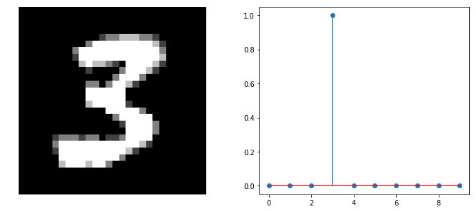

```
Prediction : 3
```

```python
test_img = test_x[np.random.choice(test_x.shape[0], 1)]

predict = model.predict_on_batch(test_img)
mypred = np.argmax(predict, axis = 1)

plt.figure(figsize = (12,5))

plt.subplot(1,2,1)
plt.imshow(test_img.reshape(28, 28), 'gray')
plt.axis('off')
plt.subplot(1,2,2)
plt.stem(predict[0])
plt.show()

print('Prediction : {}'.format(mypred[0]))
```

# 4. Lab: CNN with Tensorflow (Steel Surface Defects)

- NEU steel surface defects example
- To classify defects images into 6 classes

[figure not shown]

Download [NEU steel surface defects](http://faculty.neu.edu.cn/yunhyan/NEU_surface_defect_database.html) images and labels

- [NEU train images](https://www.dropbox.com/s/5fcdf9zfj95dztt/NEU_train_imgs.npy?dl=1)
- [NEU train labels](https://www.dropbox.com/s/0sy8nd8auwrt43m/NEU_train_labels.npy?dl=1)
- [NEU test images](https://www.dropbox.com/s/znjylp2hwnro2j6/NEU_test_imgs.npy?dl=1)
- [NEU test labels](https://www.dropbox.com/s/rm18trt9lr32bxb/NEU_test_labels.npy?dl=1)

## 4.1. Training

```python
train_x, train_y = np.load('./data_files/NEU_train_imgs.npy'), np.load('./data_files/NEU_train_labels.npy')
test_x, test_y = np.load('./data_files/NEU_test_imgs.npy'), np.load('./data_files/NEU_test_labels.npy')

train_x, test_x = train_x/255.0, test_x/255.0
train_x = train_x.reshape((train_x.shape[0], 200, 200, 1))
test_x = test_x.reshape((test_x.shape[0], 200, 200, 1))
```

```python
model = tf.keras.models.Sequential([
    tf.keras.layers.Conv2D(32,
                           (3,3),
                           activation = 'relu',
                           padding = 'SAME',
                           input_shape = (200, 200, 1)),

    tf.keras.layers.MaxPool2D((2,2)),

    tf.keras.layers.Conv2D(64,
                           (3,3),
                           activation = 'relu',
                           padding = 'SAME',
                           input_shape = (100, 100, 32)),

    tf.keras.layers.MaxPool2D((2,2)),

    tf.keras.layers.Conv2D(128,
                           (3,3),
                           activation = 'relu',
                           padding = 'SAME',
                           input_shape = (50, 50, 64)),

    tf.keras.layers.MaxPool2D((2,2)),

    tf.keras.layers.Flatten(),
    tf.keras.layers.Dense(128, activation = 'relu'),
    tf.keras.layers.Dense(6, activation = 'softmax')
])
```

```python
model.compile(optimizer = 'adam',
              loss = 'sparse_categorical_crossentropy',
              metrics = ['accuracy'])
```

```python
model.fit(train_x, train_y, epochs = 10)
```

```
<tensorflow.python.keras.callbacks.History at 0x7fdf50973ac8>
```

## 4.2. Testing or Evaluating

```python
test_loss, test_acc = model.evaluate(test_x, test_y)

print('loss = {}, Accuracy = {} %'.format(round(test_loss,2), round(test_acc*100)))
```

```
loss = 0.17, Accuracy = 94 %
```

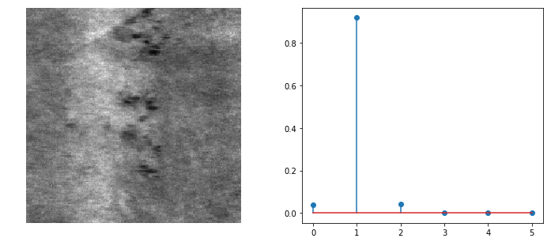

```
Prediction : rolled-in scale
Ground Truth : rolled-in scale
```

```python
name = ['scratches', 'rolled-in scale', 'pitted surface', 'patches', 'inclusion', 'crazing']

idx = np.random.choice(test_x.shape[0], 1)
test_img = test_x[idx]
GT = test_y[idx]

predict = model.predict_on_batch(test_img)
mypred = np.argmax(predict, axis = 1)

plt.figure(figsize = (12,5))

plt.subplot(1,2,1)
plt.imshow(test_img.reshape(200, 200), 'gray')
plt.axis('off')
plt.subplot(1,2,2)
plt.stem(predict[0])
plt.show()

print('Prediction : {}'.format(name[mypred[0]]))
print('Ground Truth : {}'.format(name[GT[0]]))
```